# Background and Context:

Twitter possesses 330 million monthly active users, which allows businesses to reach a broad population and connect with customers without intermediaries. On the other hand, there’s so much information that it’s difficult for brands to quickly detect negative social mentions that could harm their business.

That's why sentiment analysis/classification, which involves monitoring emotions in conversations on social media platforms, has become a key strategy in social media marketing.

Listening to how customers feel about the product/service on Twitter allows companies to understand their audience, keep on top of what’s being said about their brand and their competitors, and discover new trends in the industry.

## Data Description:

A sentiment analysis job about the problems of each major U.S. airline. Twitter data was scraped from February of 2015 and contributors were asked to first classify positive, negative, and neutral tweets, followed by categorizing negative reasons (such as "late flight" or "rude service").

### Dataset:

The dataset has the following columns:

- tweet_id
- airline_sentiment
- airline_sentiment_confidence
- negativereason
- negativereason_confidence
- airline
- airline_sentiment_gold
- name
- negativereason_gold
- retweet_count
- text
- tweet_coord
- tweet_created
- tweet_location
- user_timezone

### Objective:

To implement the techniques learned as a part of the course.

```python
# install and import necessary libraries.


import re, string, unicodedata                          # Import Regex, string and unicodedata.
import contractions                                     # Import contractions library.
from bs4 import BeautifulSoup                           # Import BeautifulSoup.

import numpy as np                                      # Import numpy.
import pandas as pd                                     # Import pandas.
import nltk                                             # Import Natural Language Tool-Kit.

nltk.download('stopwords')                              # Download Stopwords.
nltk.download('punkt')
nltk.download('wordnet')

from nltk.corpus import stopwords                       # Import stopwords.
from nltk.tokenize import word_tokenize, sent_tokenize  # Import Tokenizer.
from nltk.stem.wordnet import WordNetLemmatizer         # Import Lemmatizer.
import matplotlib.pyplot as plt                         # Import plt for visualization
```

```python
# Loading dataset
data = pd.read_csv('Tweets.csv')
```

```python
data.head()
```

|  | tweet_id | airline_sentiment | airline_sentiment_confidence | negativereason | negativereason_confidence | airline | airline_sentiment_gold | name | negativereason_gold | retweet_count | text | tweet_coord | tweet_created | tweet_location | user_timezone |
| --- | --- | --- | --- | --- | --- | --- | --- | --- | --- | --- | --- | --- | --- | --- | --- |
| 0 | 570306133677760513 | neutral | 1.0000 | NaN | NaN | Virgin America | NaN | cairdin | NaN | 0 | @VirginAmerica What @dhepburn said. | NaN | 2015-02-24 11:35:52 -0800 | NaN | Eastern Time (US & Canada) |
| 1 | 570301130888122368 | positive | 0.3486 | NaN | 0.0000 | Virgin America | NaN | jnardino | NaN | 0 | @VirginAmerica plus you've added commercials t... | NaN | 2015-02-24 11:15:59 -0800 | NaN | Pacific Time (US & Canada) |
| 2 | 570301083672813571 | neutral | 0.6837 | NaN | NaN | Virgin America | NaN | yvonnalynn | NaN | 0 | @VirginAmerica I didn't today... Must mean I n... | NaN | 2015-02-24 11:15:48 -0800 | Lets Play | Central Time (US & Canada) |
| 3 | 570301031407624196 | negative | 1.0000 | Bad Flight | 0.7033 | Virgin America | NaN | jnardino | NaN | 0 | @VirginAmerica it's really aggressive to blast... | NaN | 2015-02-24 11:15:36 -0800 | NaN | Pacific Time (US & Canada) |
| 4 | 570300817074462722 | negative | 1.0000 | Can't Tell | 1.0000 | Virgin America | NaN | jnardino | NaN | 0 | @VirginAmerica and it's a really big bad thing... | NaN | 2015-02-24 11:14:45 -0800 | NaN | Pacific Time (US & Canada) |

```python
# Shape of data
data.shape
```

```
(14640, 15)
```

```python
data.describe()
```

|  | tweet_id | airline_sentiment_confidence | negativereason_confidence | retweet_count |
| --- | --- | --- | --- | --- |
| count | 1.464000e+04 | 14640.000000 | 10522.000000 | 14640.000000 |
| mean | 5.692184e+17 | 0.900169 | 0.638298 | 0.082650 |
| std | 7.791112e+14 | 0.162830 | 0.330440 | 0.745778 |
| min | 5.675883e+17 | 0.335000 | 0.000000 | 0.000000 |
| 25% | 5.685592e+17 | 0.692300 | 0.360600 | 0.000000 |
| 50% | 5.694779e+17 | 1.000000 | 0.670600 | 0.000000 |
| 75% | 5.698905e+17 | 1.000000 | 1.000000 | 0.000000 |
| max | 5.703106e+17 | 1.000000 | 1.000000 | 44.000000 |

## EDA

```python
# Import EDA Libraries
import matplotlib.pyplot as plt
import seaborn as sns
%matplotlib inline
```

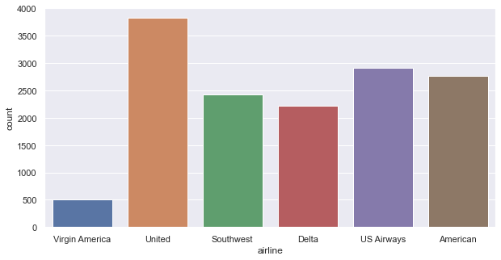

```python
# Distribution of tweets among each airline
sns.set(rc={'figure.figsize':(10,5)})
sns.countplot(data=data, x='airline')
```

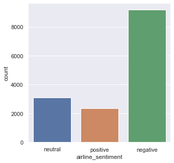

```python
# Distribution of sentiment across all tweets
sns.set(rc={'figure.figsize':(5,5)})
sns.countplot(data=data, x='airline_sentiment')
```

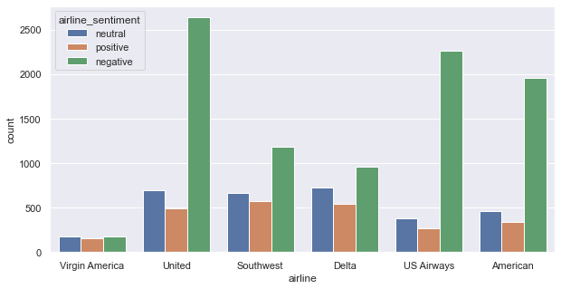

```python
# Distribution sentiment of tweets for each airline
sns.set(rc={'figure.figsize':(10,5)})
sns.countplot(data= data,x='airline', hue='airline_sentiment')
```

Looks like United, Southwest, and Delta all had around the same number of neutral and positive sentiments, and United had the most negative sentiments, followed by US Airways and American

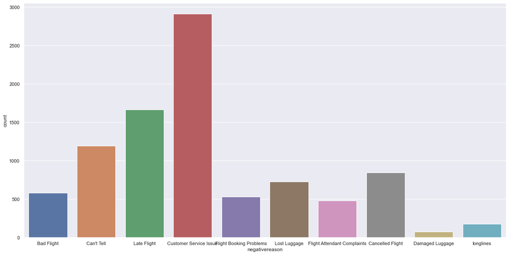

```python
sns.set(rc={'figure.figsize':(20,10)})
sns.countplot(data= data,x='negativereason')
```

Customer Service Issues were the biggest reasons for negative sentiment, and damaged luggage was the reason least tweeted about

```python
# Dropping all columns except 'text' and 'airline_sentiment'
X = pd.DataFrame()
X['text']= data['text']
X['airline_sentiment'] = data['airline_sentiment']
```

```python
X.shape
```

```
(14640, 2)
```

```python
import wordcloud
data['text'] = data.apply(lambda row: nltk.word_tokenize(row['text']), axis=1) # Tokenization of data

def show_wordcloud(data, title):
    text = ' '.join(data['text'].astype(str).tolist())                 # Converting Summary column into list
    stopwords = set(wordcloud.STOPWORDS)                                  # instantiate the stopwords from wordcloud

    fig_wordcloud = wordcloud.WordCloud(stopwords=stopwords,background_color='white',          # Setting the different parameter of stopwords
                    colormap='viridis', width=800, height=600).generate(text)

    plt.figure(figsize=(14,11), frameon=True)
    plt.imshow(fig_wordcloud)
    plt.axis('off')
    plt.title(title, fontsize=30)
    plt.show()
```

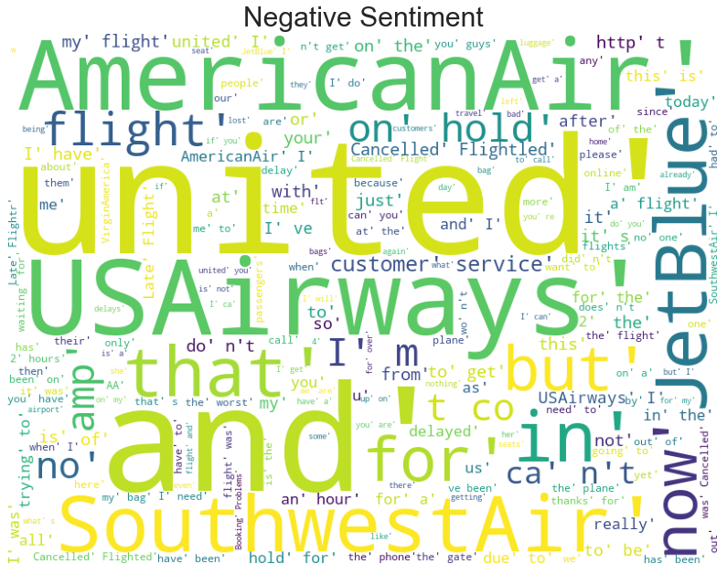

```python
# Word cloud of negative sentiment
show_wordcloud(data[data.airline_sentiment == 'negative'], title = "Negative Sentiment")
```

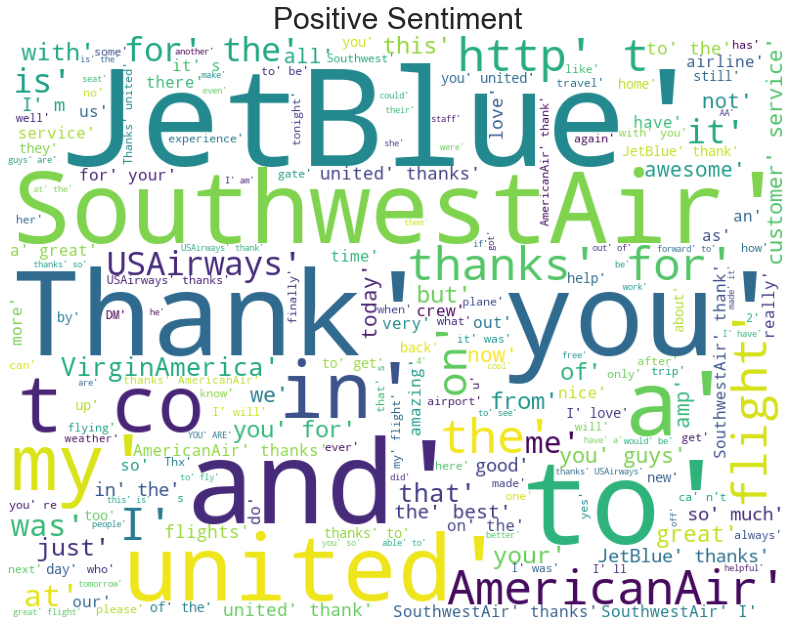

```python
# Word cloud of positive sentiment
show_wordcloud(data[data.airline_sentiment == 'positive'], title = "Positive Sentiment")
```

```python
pd.set_option('display.max_colwidth', None) # Display full dataframe information (Non-turncated Text column.)
X.head()
```

|  | text | airline_sentiment |
| --- | --- | --- |
| 0 | @VirginAmerica What @dhepburn said. | neutral |
| 1 | @VirginAmerica plus you've added commercials to the experience... tacky. | positive |
| 2 | @VirginAmerica I didn't today... Must mean I need to take another trip! | neutral |
| 3 | @VirginAmerica it's really aggressive to blast obnoxious "entertainment" in your guests' faces &amp; they have little recourse | negative |
| 4 | @VirginAmerica and it's a really big bad thing about it | negative |

## Text Preprocessing

```python
# Html tag removal
def strip_html(text):
    soup = BeautifulSoup(text, "html.parser")
    return soup.get_text()

X['text'] = X['text'].apply(lambda x: strip_html(x))
X['airline_sentiment'] = X['airline_sentiment'].apply(lambda x: strip_html(x))
```

```python
# Remove the numbers
def remove_numbers(text):
  text = re.sub(r'\d+', '', text)
  return text

X['text'] = X['text'].apply(lambda x: remove_numbers(x))
X['airline_sentiment'] = X['airline_sentiment'].apply(lambda x: remove_numbers(x))
```

```python
# Tokenization
X['text'] = X.apply(lambda row: nltk.word_tokenize(row['text']), axis=1) # Tokenization of data
X['airline_sentiment'] = X.apply(lambda row: nltk.word_tokenize(row['airline_sentiment']), axis=1) # Tokenization of data
```

```python
X.head()
```

|  | text | airline_sentiment |
| --- | --- | --- |
| 0 | [@, VirginAmerica, What, @, dhepburn, said, .] | [neutral] |
| 1 | [@, VirginAmerica, plus, you, 've, added, commercials, to, the, experience, ..., tacky, .] | [positive] |
| 2 | [@, VirginAmerica, I, did, n't, today, ..., Must, mean, I, need, to, take, another, trip, !] | [neutral] |
| 3 | [@, VirginAmerica, it, 's, really, aggressive, to, blast, obnoxious, ``, entertainment, '', in, your, guests, ', faces, &, they, have, little, recourse] | [negative] |
| 4 | [@, VirginAmerica, and, it, 's, a, really, big, bad, thing, about, it] | [negative] |

```python
lemmatizer = WordNetLemmatizer()
stopwords = stopwords.words('english')

def remove_non_ascii(words):
    """Remove non-ASCII characters from list of tokenized words"""
    new_words = []
    for word in words:
        new_word = unicodedata.normalize('NFKD', word).encode('ascii', 'ignore').decode('utf-8', 'ignore')
        new_words.append(new_word)
    return new_words

def to_lowercase(words):
    """Convert all characters to lowercase from list of tokenized words"""
    new_words = []
    for word in words:
        new_word = word.lower()
        new_words.append(new_word)
    return new_words

def remove_punctuation(words):
    """Remove punctuation from list of tokenized words"""
    new_words = []
    for word in words:
        new_word = re.sub(r'[^\w\s]', '', word)
        if new_word != '':
            new_words.append(new_word)
    return new_words

def remove_stopwords(words):
    """Remove stop words from list of tokenized words"""
    new_words = []
    for word in words:
        if word not in stopwords:
            new_words.append(word)
    return new_words

def lemmatize_list(words):
    new_words = []
    for word in words:
      new_words.append(lemmatizer.lemmatize(word, pos='v'))
    return new_words

def normalize(words):
    words = remove_non_ascii(words)
    words = to_lowercase(words)
    words = remove_punctuation(words)
    words = remove_stopwords(words)
    words = lemmatize_list(words)
    return ' '.join(words) # Join words in list

X['text'] = X.apply(lambda row: normalize(row['text']), axis=1)
X['airline_sentiment'] = X.apply(lambda row: normalize(row['airline_sentiment']), axis=1)
X.head()
```

|  | text | airline_sentiment |
| --- | --- | --- |
| 0 | virginamerica dhepburn say | neutral |
| 1 | virginamerica plus add commercials experience tacky | positive |
| 2 | virginamerica nt today must mean need take another trip | neutral |
| 3 | virginamerica really aggressive blast obnoxious entertainment guests face little recourse | negative |
| 4 | virginamerica really big bad thing | negative |

# Vectorization

### CountVectorizer

```python
# Vectorization (Convert text data to numbers).
from sklearn.feature_extraction.text import CountVectorizer

bow_vec = CountVectorizer(max_features=2000)                # Keep only 2000 features as number of features will increase the processing time.
data_features = bow_vec.fit_transform(X['text'])

data_features = data_features.toarray()                        # Convert the data features to array.
```

```python
data_features.shape
```

```
(14640, 2000)
```

```python
# Split data into training and testing set.

from sklearn.model_selection import train_test_split

X_train, X_test, y_train, y_test = train_test_split(data_features, X['airline_sentiment'], test_size=0.3, random_state=42)
```

```python
# Using Random Forest to build model for the classification of reviews.
# Also calculating the cross validation score.

from sklearn.ensemble import RandomForestClassifier
from sklearn.model_selection import cross_val_score

forest = RandomForestClassifier(n_estimators=10, n_jobs=4)

forest = forest.fit(X_train, y_train)

print(forest)

print(np.mean(cross_val_score(forest, data_features, X['airline_sentiment'], cv=10)))
```

```
RandomForestClassifier(n_estimators=10, n_jobs=4)
0.7090163934426229
```

- This accuracy is okay, but there is a lot of room for improvement

### Tuning

```python
# Finding optimal number of base learners using k-fold CV ->
base_ln = [x for x in range(1, 25)]
base_ln
```

```
[1,
 2,
 3,
 4,
 5,
 6,
 7,
 8,
 9,
 10,
 11,
 12,
 13,
 14,
 15,
 16,
 17,
 18,
 19,
 20,
 21,
 22,
 23,
 24]
```

```python
# K-Fold Cross - validation .
cv_scores = []
for b in base_ln:
    clf = RandomForestClassifier(n_estimators = b)
    scores = cross_val_score(clf, X_train, y_train, cv = 5, scoring = 'accuracy')
    cv_scores.append(scores.mean())
```

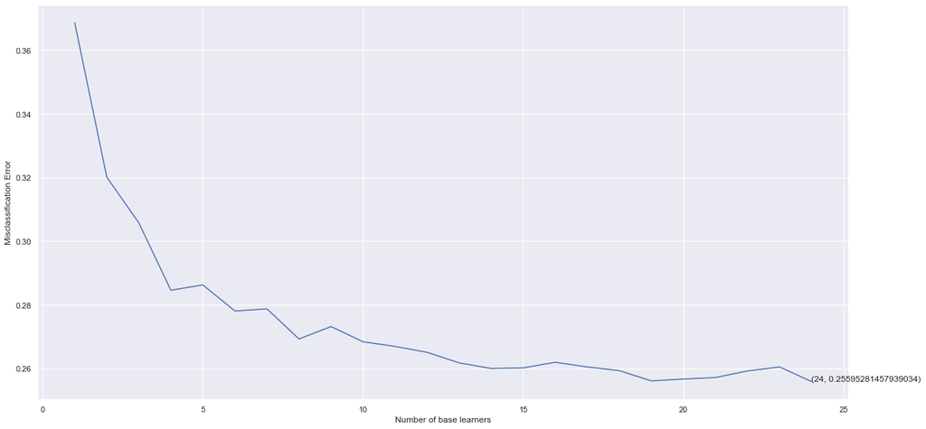

```python
# plotting the error as k increases
error = [1 - x for x in cv_scores]                                 #error corresponds to each nu of estimator
optimal_learners = base_ln[error.index(min(error))]                #Selection of optimal nu of n_estimator corresponds to minimum error.
plt.plot(base_ln, error)                                           #Plot between each nu of estimator and misclassification error
xy = (optimal_learners, min(error))
plt.annotate('(%s, %s)' % xy, xy = xy, textcoords='data')
plt.xlabel("Number of base learners")
plt.ylabel("Misclassification Error")
plt.show()
```

```python
# Training the best model and calculating accuracy on test data .
clf = RandomForestClassifier(n_estimators = optimal_learners)
clf.fit(X_train, y_train)
clf.score(X_test, y_test)
```

```
0.7723132969034608
```

- This is much improved over the original model

```
[[2529  204   81]
 [ 371  432   81]
 [ 167   96  431]]
0.7723132969034608
```

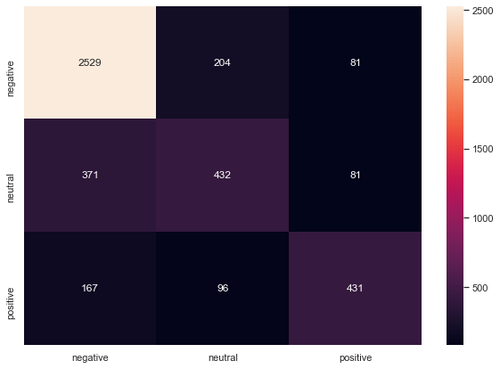

```python
result =  clf.predict(X_test)                  #saving the prediction on test data as a result
# Print and plot Confusion matirx to get an idea of how the distribution of the prediction is, among all the classes.

from sklearn import metrics
from sklearn.metrics import confusion_matrix

conf_mat = confusion_matrix(y_test, result)

print(conf_mat)

print(metrics.f1_score(y_test, result,average='micro'))

df_cm = pd.DataFrame(conf_mat, index = ['negative', 'neutral', 'positive'], columns =['negative', 'neutral', 'positive'])
plt.figure(figsize = (10,7))
sns.heatmap(df_cm, annot=True, fmt='g')
```

- It seems this model tends to predict sentiments as negative

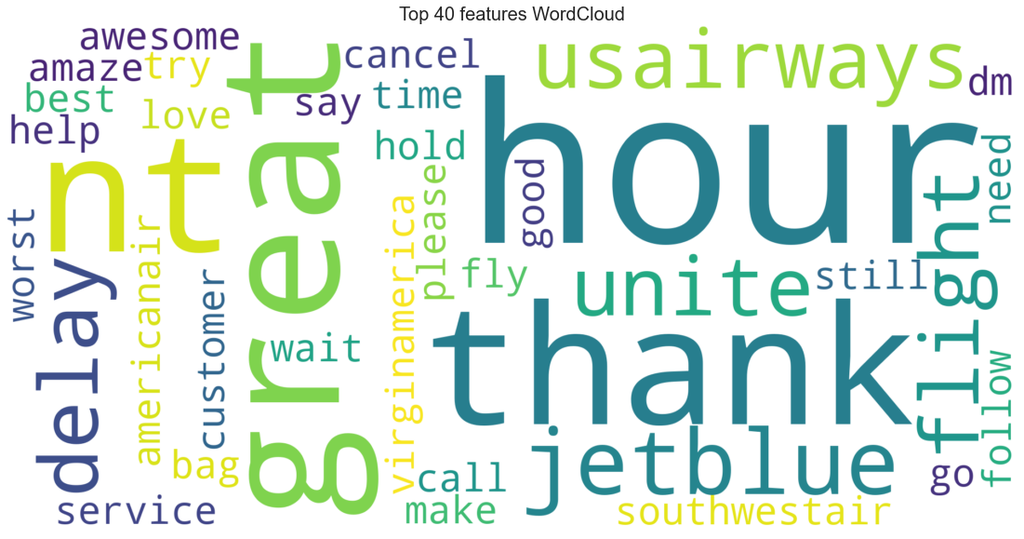

```python
# Word cloud of top 40 features
all_features = bow_vec.get_feature_names()              #Instantiate the feature from the vectorizer
top_features=''                                            # Addition of top 40 feature into top_feature after training the model
feat=clf.feature_importances_
features=np.argsort(feat)[::-1]
for i in features[0:40]:
    top_features+=all_features[i]
    top_features+=' '


from wordcloud import WordCloud
wordcloud = WordCloud(background_color="white",colormap='viridis',width=2000,
                          height=1000).generate(top_features)

# Display the generated image:
plt.imshow(wordcloud, interpolation='bilinear')
plt.figure(1, figsize=(14, 11), frameon='equal')
plt.title('Top 40 features WordCloud', fontsize=20)
plt.axis("off")
plt.show()
```

- a few top features indicate delays ("wait", "delay", "hour", "time")

## TF-IDF

```python
# Using TfidfVectorizer to convert text data to numbers.

from sklearn.feature_extraction.text import TfidfVectorizer

vectorizer = TfidfVectorizer(max_features=2000)
data_features = vectorizer.fit_transform(X['text'])

data_features = data_features.toarray()

data_features.shape
```

```
(14640, 2000)
```

```python
# Split data into training and testing set.

from sklearn.model_selection import train_test_split

X_train, X_test, y_train, y_test = train_test_split(data_features, X['airline_sentiment'], test_size=0.3, random_state=7)
```

```python
# Using Random Forest to build model for the classification of reviews.
# Also calculating the cross validation score.


forest = RandomForestClassifier(n_estimators=10, n_jobs=4)

forest = forest.fit(X_train, y_train)

print(forest)

print(np.mean(cross_val_score(forest, data_features, X['airline_sentiment'], cv=5)))
```

```
RandomForestClassifier(n_estimators=10, n_jobs=4)
0.6900956284153005
```

- So far the accuracy score is a little worse than the initial BoW model

### Tuning

```python
# K - Fold Cross Validation .
cv_scores = []
for b in base_ln:
    clf = RandomForestClassifier(n_estimators = b)
    scores = cross_val_score(clf, X_train, y_train, cv = 5, scoring = 'accuracy')
    cv_scores.append(scores.mean())
```

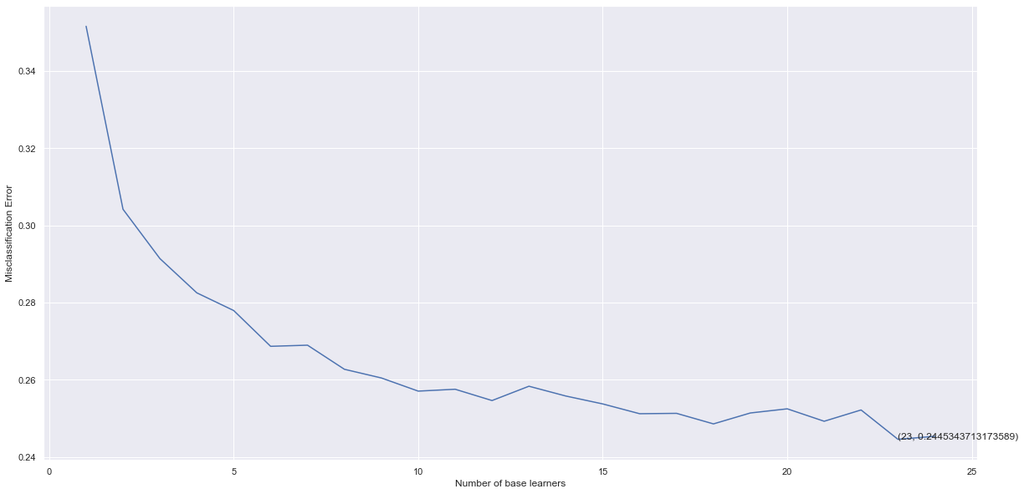

```python
# plotting the error as k increases
error = [1 - x for x in cv_scores]                                              #error corresponds to each nu of estimator
optimal_learners = base_ln[error.index(min(error))]                             #Selection of optimal nu of n_estimator corresponds to minimum error.
plt.plot(base_ln, error)                                                        #Plot between each nu of estimator and misclassification error
xy = (optimal_learners, min(error))
plt.annotate('(%s, %s)' % xy, xy = xy, textcoords='data')
plt.xlabel("Number of base learners")
plt.ylabel("Misclassification Error")
plt.show()
```

```python
# Training the best model and calculating error on test data .
clf = RandomForestClassifier(n_estimators = optimal_learners)
clf.fit(X_train, y_train)
clf.score(X_test, y_test)
```

```
0.7563752276867031
```

- This is better than the first model but still inferior to the second BoW model

```
[[2594  126   64]
 [ 475  368   87]
 [ 222   96  360]]
0.7563752276867031
```

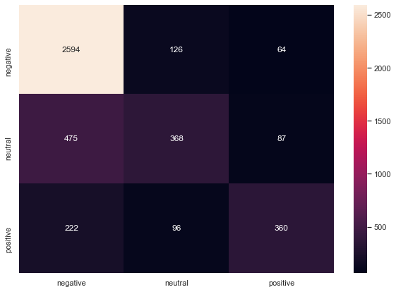

```python
# Print and plot Confusion matirx to get an idea of how the distribution of the prediction is, among all the classes.
result =  clf.predict(X_test)
import matplotlib.pyplot as plt
import seaborn as sns
from sklearn import metrics
from sklearn.metrics import confusion_matrix

conf_mat = confusion_matrix(y_test, result)

print(conf_mat)

print(metrics.f1_score(y_test, result,average='micro'))

df_cm = pd.DataFrame(conf_mat, index = ['negative', 'neutral', 'positive'], columns =['negative', 'neutral', 'positive'])
plt.figure(figsize = (10,7))
sns.heatmap(df_cm, annot=True, fmt='g')
```

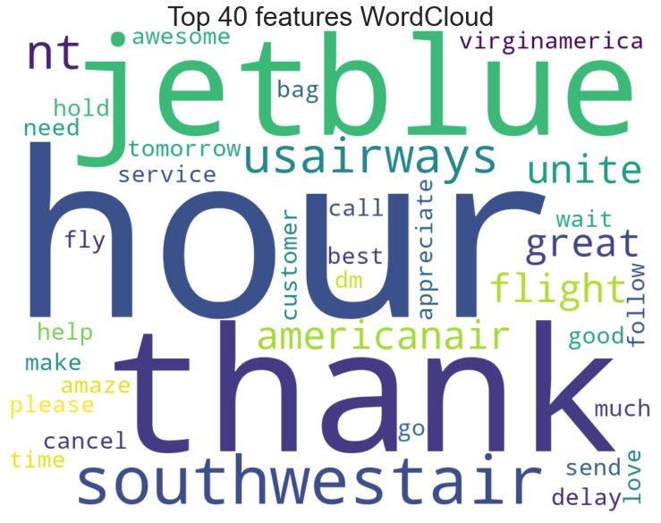

```python
# Word cloud of the top 40 words
all_features = vectorizer.get_feature_names()                                #Instantiate the feature from the vectorizer
Top_features=''                                                              #Addition of top 40 feature into top_feature after training the model
feat=clf.feature_importances_
features=np.argsort(feat)[::-1]
for i in features[0:40]:
    Top_features+=all_features[i]
    Top_features+=' '


from wordcloud import WordCloud
wordcloud = WordCloud(background_color="White",width=1000,
                          height=750).generate(Top_features)

# Display the generated image:
plt.imshow(wordcloud, interpolation='bilinear')
plt.figure(1, figsize=(30, 30), frameon='equal')
plt.title('Top 40 features WordCloud', fontsize=30)
plt.axis("off")
plt.show()
```

- Like the last model, this model makes a lot of references to delays and time
- This list also cites a few words related to service ("service", "help", "hold", "call", "customer")

# Conclusion

- It appears that the biggest factors that contributed to whether a tweet would be flagged as positive or negative were words that referenced service or flight delays
- This is reinforced by the EDA which found that bad service and cancelled or delayed flights were the most often cited reasons for a negative sentiment
- This is also supported by the fact that words like "appreciate", "great", "help", "amaze" and "thank" were top features, indicating that a positive customer service experience was very influential in how they tweeted